# Time Series Analysis Assignment 3

#### b) Examine the residuals of an AR(2) model fit to Series Z and describe what you find.

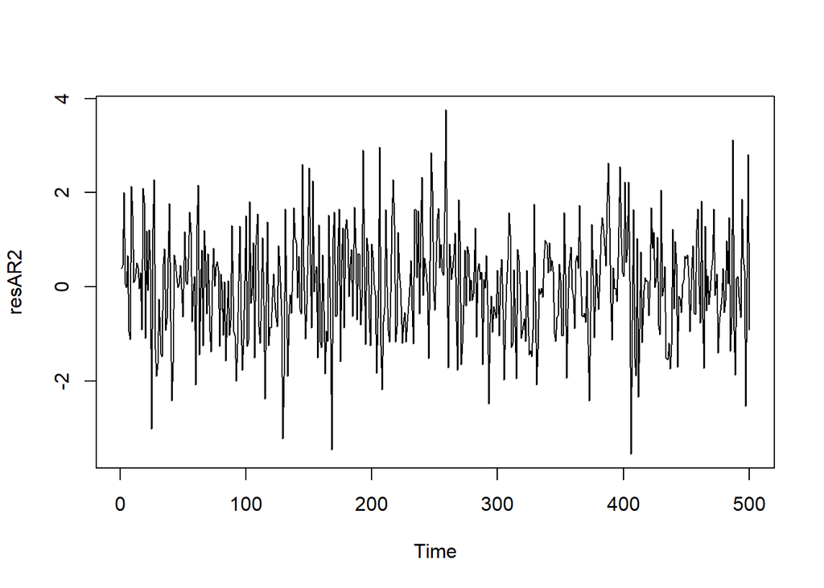

```r
modelAR2 = arima(Z, order = c(2,0,0), include.mean = FALSE)
resAR2 = residuals(modelAR2)
plot(resAR2)
```

```r
mean(resAR2)
```

```
## [1] 0.01680712
```

```r
var(resAR2)
```

```
## [1] 1.282354
```

Plot of residuals looks to be distributed as a white noise. Mean of residuals roughly 0 & variance roughly 1.28.

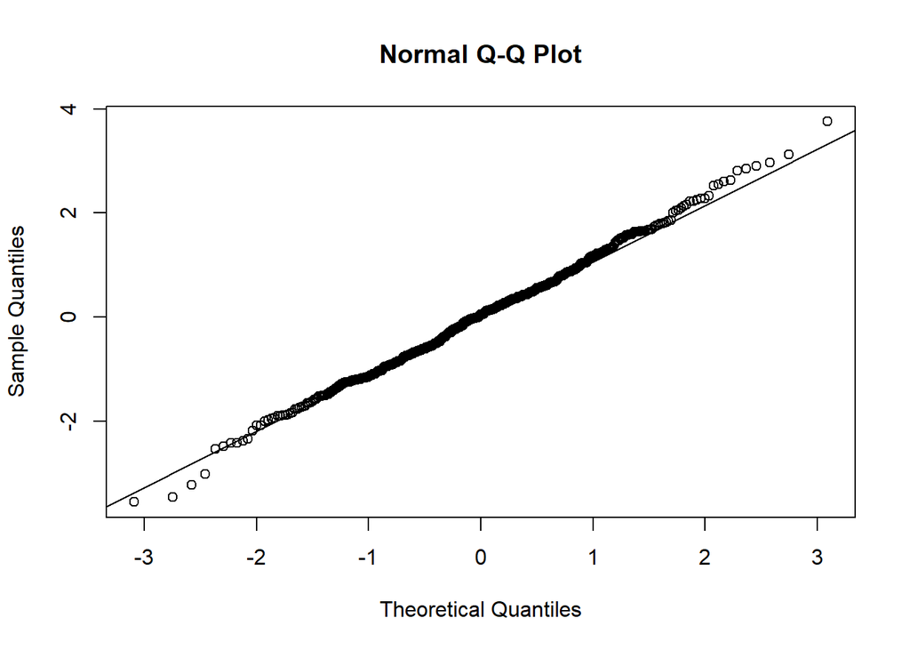

```r
qqnorm(resAR2)
qqline(resAR2)
```

```r
shapiro.test(resAR2) # p-value of 0.6861. Fail to reject normality hypothesis
```

```
##
##  Shapiro-Wilk normality test
##
## data:  resAR2
## W = 0.99757, p-value = 0.6861
```

QQ-Plot seems fine as well, p-value on the Shapiro-Wilk test of 0.6861 means we do not reject the normality hypothesis on the residuals at 5% significance level.

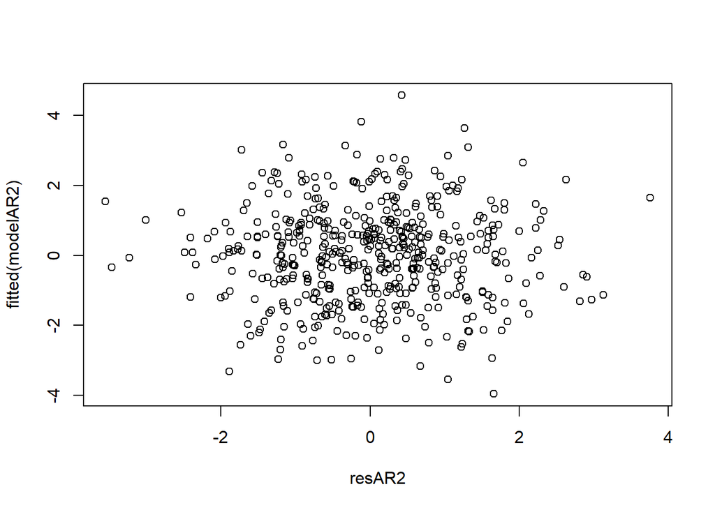

```r
plot(resAR2, fitted(modelAR2)) # no obvious pattern in residuals
```

There is no obvious pattern in the plot of residuals vs fitted values.

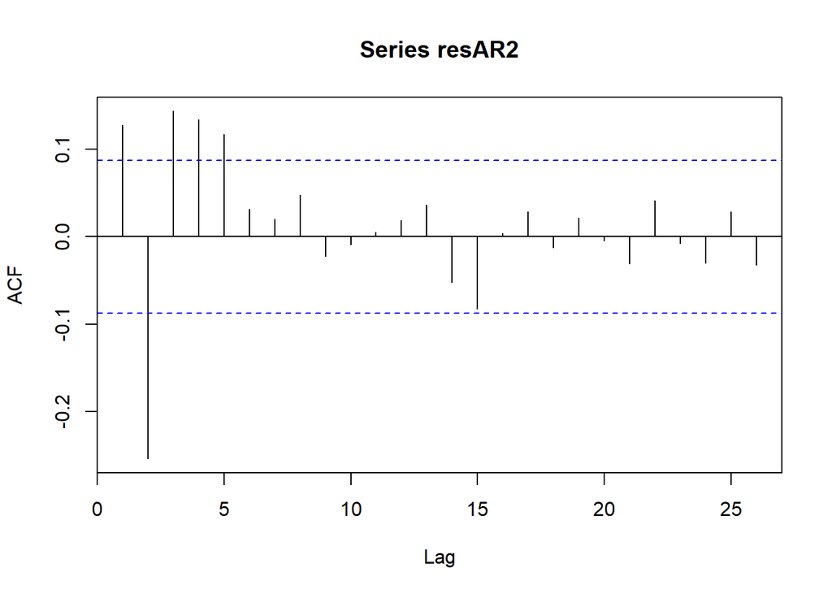

```r
acf(resAR2) # ACF not null for lags less than 5 time steps
```

```r
Box.test(resAR2, lag = 12, type = "Ljung-Box", fitdf = 2)
```

```
##
##  Box-Ljung test
##
## data:  resAR2
## X-squared = 69.605, df = 10, p-value = 5.285e-11
```

```r
# p-value = 5.285e-11. Reject hypothesis that residuals distributed as a white noise.
```

ACF plot of residuals shows that there is non-null autocorrelation for lags less than 5, indicating that we may have chosen a q value which may be too small. Ljung-Box test reports a p-value of 5.285e-11, meaning we reject the hypothesis that the residuals are distributed as a white noise.

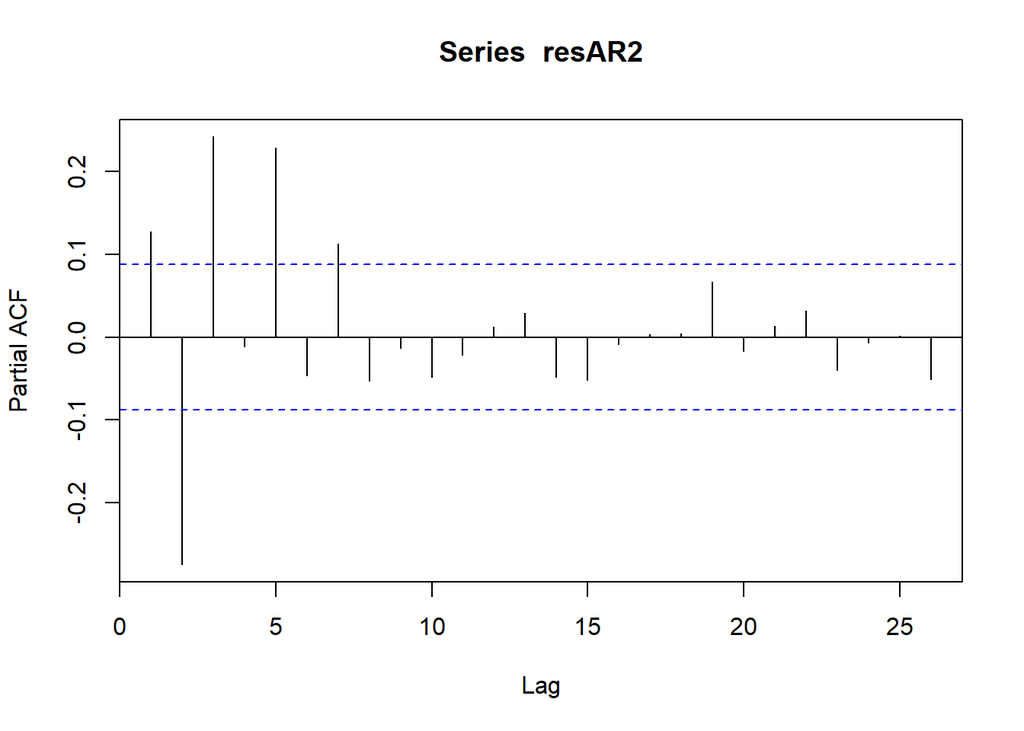

```r
pacf(resAR2) # PACF not null for lags 1, 2, 3, 5 & 7
```

PACF plot not null for lags 1, 2, 3, 5 & 7, indicating that we may not have chosen a large enough value of p.

## Exercise 3

Now fit an AR(10) model to Series Z.

#### a) Are the parameters significant? Examine the residuals and describe your findings.

```r
modelZ10 = arima(Z, order = c(10, 0, 0), include.mean = FALSE)
coeftest(modelZ10)
```

```
##
## z test of coefficients:
##
##       Estimate Std. Error  z value  Pr(>|z|)
## ar1   1.243151   0.044721  27.7977 < 2.2e-16 ***
## ar2  -1.021776   0.071533 -14.2840 < 2.2e-16 ***
## ar3   0.864821   0.084612  10.2210 < 2.2e-16 ***
## ar4  -0.629263   0.092152  -6.8285 8.578e-12 ***
## ar5   0.559293   0.094632   5.9102 3.417e-09 ***
## ar6  -0.435401   0.094739  -4.5958 4.311e-06 ***
## ar7   0.321994   0.092804   3.4696 0.0005212 ***
## ar8  -0.208950   0.085816  -2.4348 0.0148983 *
## ar9   0.075427   0.072839   1.0355 0.3004238
## ar10 -0.021601   0.045484  -0.4749 0.6348375
## ---
## Signif. codes:  0 '***' 0.001 '**' 0.01 '*' 0.05 '.' 0.1 ' ' 1
```

```r
# first 8 paramaeters are significant
# may be due to fact that any ARMA(p, q) model with |phiK| <= 1 for all K can be approximated by an AR(k) model where k is large
```

```r
res10 = residuals(modelZ10)
mean(res10)
```

```
## [1] 0.01096226
```

```r
var(res10)
```

```
## [1] 1.013757
```

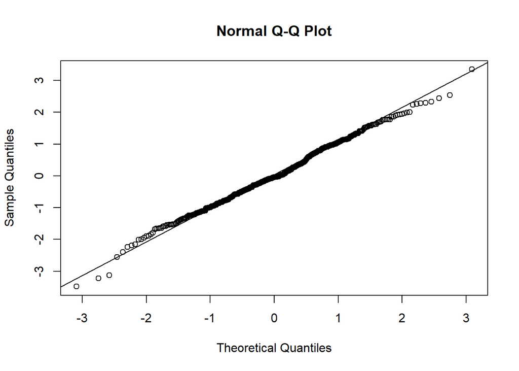

```r
qqnorm(res10)
qqline(res10)
```

```r
shapiro.test(res10)
```

```
##
##  Shapiro-Wilk normality test
##
## data:  res10
## W = 0.99586, p-value = 0.2136
```

```r
# p-value of 0.2136, fail to reject normality hypothesis at 5% significance
```

QQ-Plot seems fine as well, p-value on the Shapiro-Wilk test of 0.2136 means we do not reject the normality hypothesis on the residuals at 5% significance level.

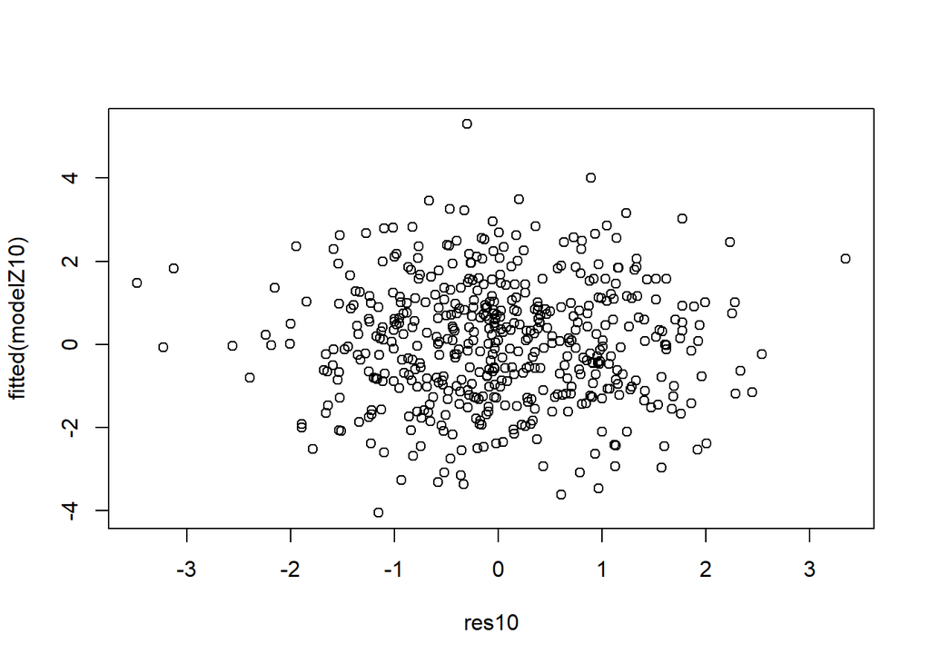

```r
plot(res10, fitted(modelZ10)) # no obvious pattern in residuals
```

There is no obvious pattern in the plot of residuals vs fitted values.

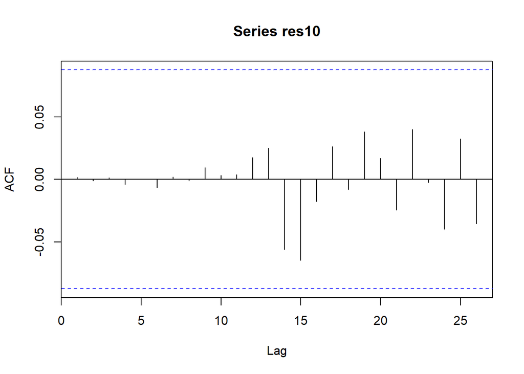

```r
acf(res10) # acf of residuals null for all lags
```

```r
Box.test(res10, lag = 20, type = "Ljung-Box", fitdf = 10)
```

```
##
##  Box-Ljung test
##
## data:  res10
## X-squared = 5.8535, df = 10, p-value = 0.8274
```

```r
# p-value = 0.8274. Fail to reject hypothesis that residuals distributed as a white noise.
```

ACF plot of the residuals null for all lags, indicating that we have chosen a sufficient value of q. The Ljung-Box test reports a p-value of 0.8274, meaning we fail to reject null hypothesis that residuals are distributed as a white noise.

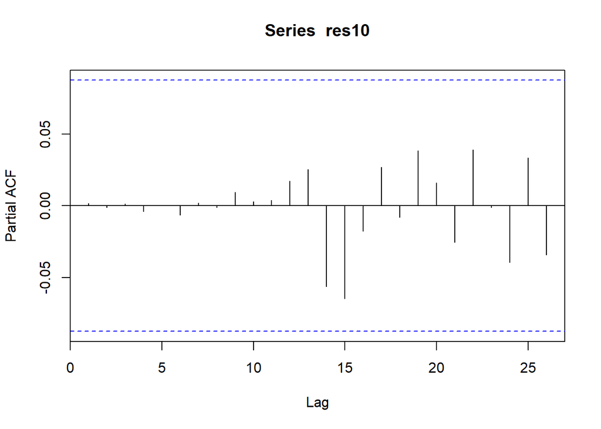

```r
pacf(res10) # pacf of residuals null for all lags
```

PACF plot shows null values for all lags, indicating that we have chosen a sufficient value of p.

#### b) Why might this model fit the Series well?

This model may suit the series well as any ARMA(p, 1) can be approximated by an AR(K) model for K large enough. As we are using a large value of p (10) for our model, the approximation works well.